# Solemne 1, parte R. Pauta de corrección.

Ricardo Mayer

2019-11-04

Comentario general: Una parte de los objetivos es aprender el uso de R, aunque el objetivo principal sigue siendo *hacer estadística correctamente* usando R. Por esa razón el uso de de las funciones adecuadas recibe *algo* de puntaje (típicamente un cuarto del puntaje), aunque no estén correctamente empleadas en el contexto del problema planteado. En la próxima evaluación probablemnete ya no no hay puntaje asignado por usar incorrectamente la función correcta.

```r
# No olvide ejecutar las líneas 2 y 6 antes de empezar el resto del trabajo
library(readxl)
```

```r
misdatos <- read_excel("datos_e.xlsx")
```

2. Para las variables “pib_per_capita” y “esperanza_de_vida” compute lo siguiente 2.1 la media cada una (4 pts) 2.2 la desviación estandar de cada una (4 pts) 2.3 la cantidad de observaciones (n) de cada una (4 pts)

```r
# Para "esperanza de vida"
evi <- misdatos$esperanza_de_vida
emu <- mean(evi)
esd <- sd(evi)
en <- length(evi)

c(emu, esd, en)
```

```
## [1]  67.00742  12.07302 142.00000
```

```r
# Para "pib per capita"
ppc <- misdatos$pib_per_capita
pmu <- mean(ppc)
psd <- sd(ppc)
pn <- length(ppc)

c(pmu, psd, pn)
```

```
## [1] 11680.07 12859.94   142.00
```

```r
# Notas para la corrección:
# - no es necesario que la consola muestre los valores, sólo calcularlos
# - no es necesario guardar los resultados en objetos (i.e. usar <- )
# - la solución a 2.3 puede tomar otras formas como por ejemplo nrow(misdatos) o
#    incluso dim(misdatos). Otras formas menos aceptables incluyen mirar en el environment
#  cuantas observaciones tiene misdatos, o imprimir misdatos$pib_per_capita y mirar
# en la consola la cantidad de elementos. En estos ultimos casos se lleva solamente 2 puntos.
```

3. Grafique los histogramas de estas tres variables: “pib_per_capita” (2 pto),, “esperanza_de_vida” (2 pto), y el logaritmo natural de la variable “población” (4 pts). Puede usar cualquier función y paquete de R que grafique histogramas

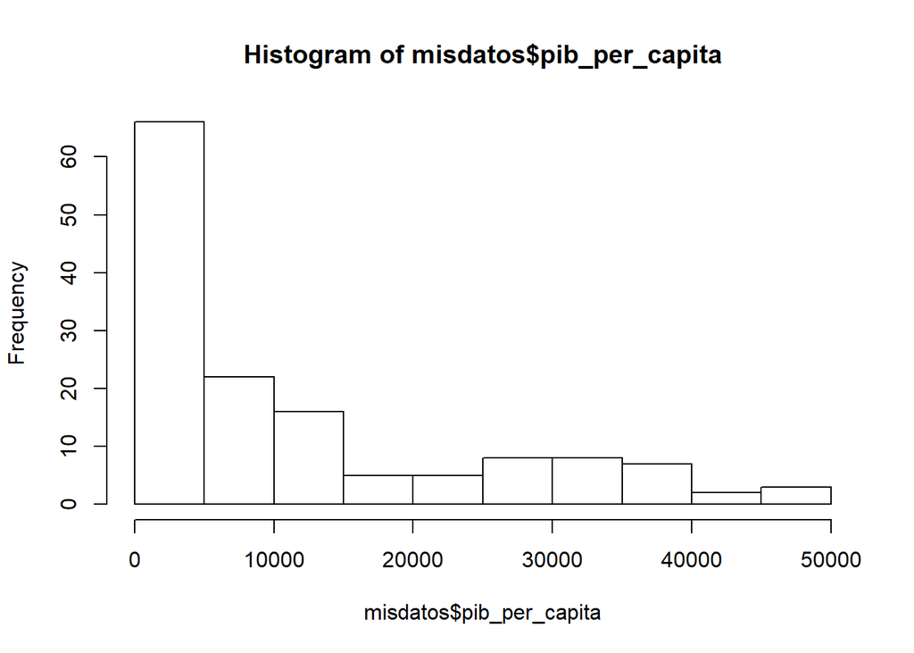

```r
hist(misdatos$pib_per_capita, breaks = 15)
```

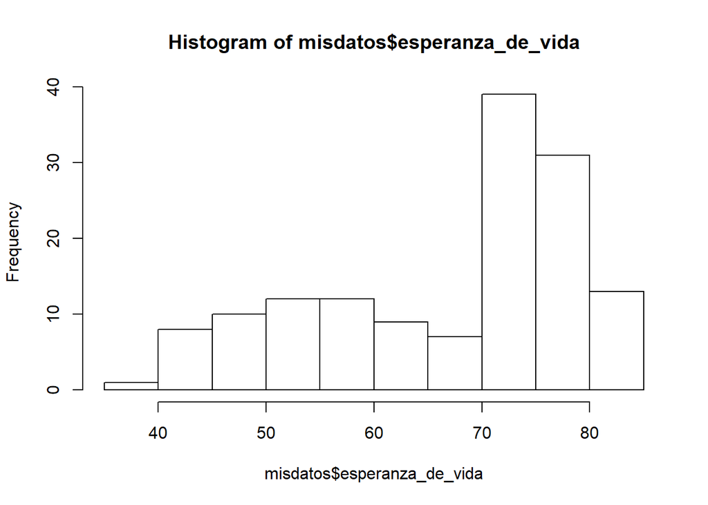

```r
hist(misdatos$esperanza_de_vida, breaks = 15)
```

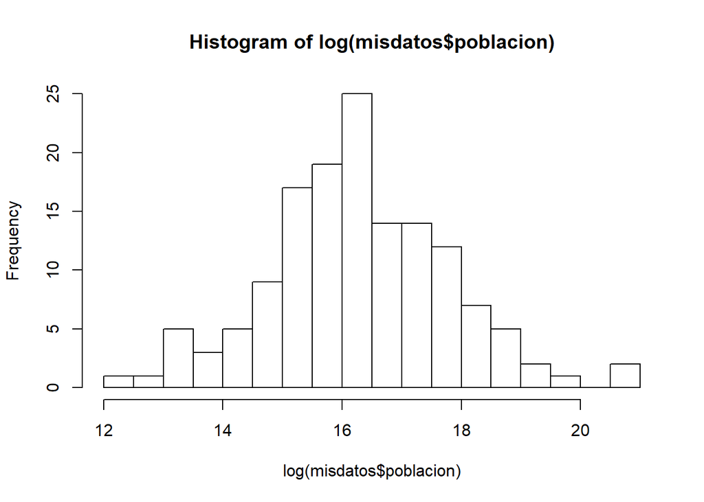

```r
hist(log(misdatos$poblacion), breaks = 15)
```

```r
# Notas para la corrección:
# - Cualquier función que grafique un histograma está OK
# - los detalles (como número de breaks) no inciden en el puntaje asignado
# - usar correctamente la función hist (o similar) pero con la variable incorrecta
#  tiene 0.5 puntos
# - usar correctamente la función hist (o similar) y usar la variable  población
# pero fallar en usar el logaritmo natural de población tiene 1 punto
```

**Procedimiento para pedir recorreción**: Si Ud. encuentra algún error en el puntaje asignado según esta pauta, puede solicitar una reevaluación de la siguiente manera:

- Tome el script que usted escribió durante la solemne y asigne, como comentarios en el script, los puntos que usted considere adecuado *de acuerdo a la pauta de corrección*.
- Calcule el puntaje total y compárelo con el puntaje que obtuvo en esta corrección.
- Si ambos puntajes difieren, envíe un correo a su profesor, adjuntando su script con su propia corrección.